# Walmart TripType Classification

Oscar Daniel Camarena, Maximiliano Alvarez, Patricio Hernandez

11 de diciembre de 2016

# 1 Solucion al problema de clasificacion de tipos de viaje a Walmart

## 1.1 Introduccion

Whether they’re on a last minute run for new puppy supplies or leisurely making their way through a weekly grocery list, classifying trip types enables Walmart to create the best shopping experience for every customer. Currently, Walmart’s trip types are created from a combination of existing customer insights (“art”) and purchase history data (“science”). In their third recruiting competition, Walmart is challenging Kagglers to focus on the (data) science and classify customer trips using only a transactional dataset of the items they’ve purchased. Improving the science behind trip type classification will help Walmart refine their segmentation process.

## 1.2 Datos

Veamos el data set de Walmart

```r
head(train)
```

|  | TripType | VisitNumber | Weekday | Upc | ScanCount | DepartmentDescription | FinelineNumber |
| --- | --- | --- | --- | --- | --- | --- | --- |
| 1 | 999 | 5 | Friday | 68113152929 | -1 | FINANCIAL SERVICES | 1000 |
| 2 | 30 | 7 | Friday | 60538815980 | 1 | SHOES | 8931 |
| 3 | 30 | 7 | Friday | 7410811099 | 1 | PERSONAL CARE | 4504 |
| 4 | 26 | 8 | Friday | 2238403510 | 2 | PAINT AND ACCESSORIES | 3565 |
| 5 | 26 | 8 | Friday | 2006613744 | 2 | PAINT AND ACCESSORIES | 1017 |
| 6 | 26 | 8 | Friday | 2006618783 | 2 | PAINT AND ACCESSORIES | 1017 |

Contenido de las Columnas:

- TripType - 38 tipos de viajes diferentes creados por Walmart -> La respuesta de este ejercicio
- Visit Number - Identificador único de cada viaje particular, tenemos +90,000 viajes en total
- Weekday - Variable categórica que indica el día de la semana en la que ocurrió el viaje
- UPC - código de barras del producto comprado
- ScanCount - Cantidad de items comprados para cierto producto, si se trata de una devolución se tendrá un número negativo
- Department Description - 72 categorías de productos creadas por Walmart
- Fineline Number - 5000 clasificaciones de productos refinadas

## 1.3 Metodología para resolver esta competencia

Luego de una etapa de investigación, comprendimos que la mejor estrategía a seguir para resolver este tipo de competencias es la siguiente:

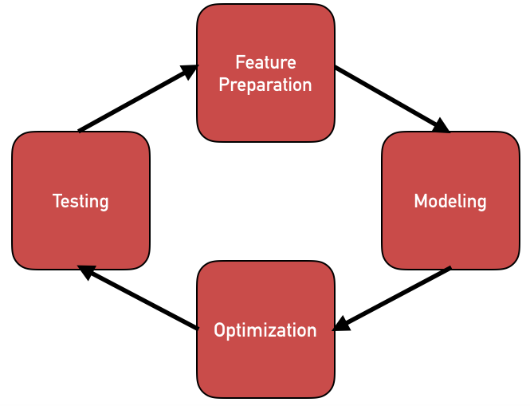

La preparación de características (Feature Preparation) se refiere a la transformación de los datos “en crudo” a datos que sirvan de input para que algoritmos de aprendizaje puedan leer y aprender. Una vez que se tienen los datos listos se debe correr el modelo, mejorar el desempeño y optimizar los parámetros del modelo, y asi, al finalizar el modelo estará listo para probar datos sin clasificación previa.

## 1.4 Analizis de datos

Antes de empezar a preparar los datos para ser procesados por algorítmos de aprendizaje de máquina, analizamos los datos para comprender que es lo que hay detrás de ellos. Una herramienta de mucha ayuda es el heatmap, que nos permite ver como se relacionan los departamentos con los tipos de viajes

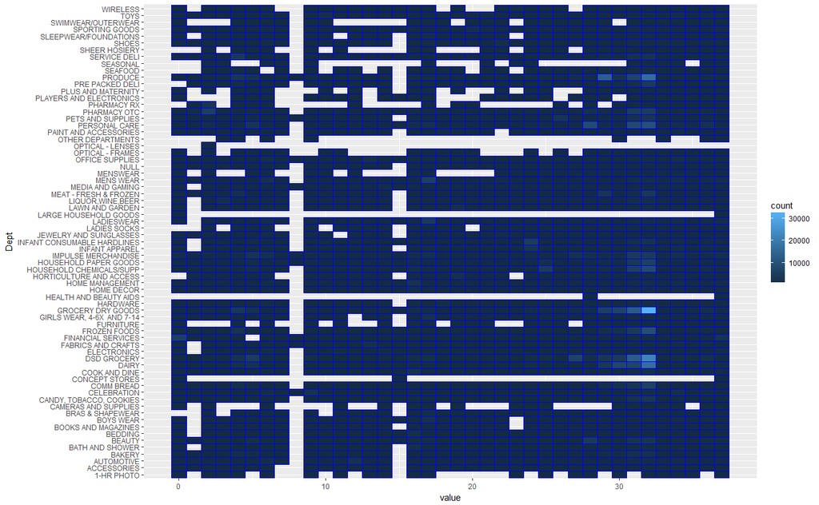

## 1.5 Preparación de Variables

Crear datos que permitan que un modelo aprenda puede ser la parte mas importante del proceso. La ayuda del dominio del negocio es de mucha ayuda en esta etapa. Basados en nuestro análisis de la información creamos las siguientes variables:

Nos dimos cuenta que el set de pruebas no contenía un departamento que si tiene el set de entrenamiento. El primer paso fue quitar este departamento del set de entrenamiento: *HEALTH AND BEAUTY AIDS*

- Renombramos la columna *TargetType* dado que esta columna va con numeros no continuos, la renombramos para tener una salida que vaya del 0 al 37 sin *huecos*.
- Transformamos el dataset para que cada renglon corresponda a un viaje individual *VisitNumber* y cada columna representa el número de artículos comprados en cada uno de los departamentos (esto nos generó mas de 70 variables nuevas)
- Introdujimos nuevas variables:
  - Total de productos escáneados por *VisitNumber*
  - Indicador de producto regresado por *VisitNumber*
  - Total de departamentos visitados por *VisitNumber*
  - Total de productos *FinelineNumber* comprados por *VisitNumber*
  - Total de productos *UPC* comprados por *VisitNumber*
  - **MIN**, **MAX**, **RANGE** de productos comprados por *VisitNumber* en cada uno de los distintos departamentos
- Categorizamos *Weekday*
- Categorizamos *TripType*

Una vez hecho esto estamos listos para pasar al modelado

## 1.6 Modelado - Apliquemos machine learning

El objetivo de este proyecto era aplicar 3 algorítmos de aprendizaje de máquina que nos ayudaran a clasificar el dataset de pruebas y medir nuestro score en [Kaggle](https://www.kaggle.com/c/walmart-recruiting-trip-type-classification)

### 1.6.1 Algoritmo 1 -> KNN

El primer algorítmo que aplicamos fue el **KNN** utilizando 5 vecinos cercanos, y una votación mínima = 0.

Al aplicar este algoritmo tuvimos que aplicar una columna de ruído al dataset, ya que al intentar predecir la clasificaciónd el set de **Pruebas** notamos que había muchos empates en la clasificación de salida.

### 1.6.2 Algoritmo 2 -> XGBoost

Se utilizó cross validation para el entrenamiento del modelo con los siguientes parámetros:

- Round = 50
- Folds = 5

### 1.6.3 Alogritmo 3 -> RandomForest

Por último aplicamos un **RandomForest**, para poder hacer esto tuvimos que cambiar los nombres de todas las variables por nombres *Tidy* es decir, sin espacios.

## 1.7 Conclusiones

Aunque teníamos más de 370 variables en nuestros datasets el desempeño de nuestros modelos fue promedio. Los scores obtenidos en Kaggle fueron por debajo del lugar **850** por lo que nos dimos a la tarea de generar una cuarto algorítmo simplificando el número de variables que se utilizan. El cuarto algorítmo se trató de una **Regresión logística** bajo la técnica *1 vs All* y los resultados fueron más alentadores

## 1.8 Regresión logística

Se codificó una regresión logística en **python** utilizando un número menor de variables, a continuación se presenta el código utilizado:

```r
import pandas as pd
import numpy as np
import scipy as sp
from sklearn.linear_model import LogisticRegression
import time

start_time = time.time()

waltrain = pd.read_csv('C:/Users/lucky/Documents/Ciencia de Datos/Aprendizaje de Maquina/Proyecto Final ML/train/train.csv')
waltest = pd.read_csv('C:/Users/lucky/Documents/Ciencia de Datos/Aprendizaje de Maquina/Proyecto Final ML/test/test.csv')
waltrain = waltrain[waltrain.FinelineNumber.notnull()]
waltrain_part = waltrain[:]
waltest_part = waltest[:]

model = LogisticRegression()
x = waltrain_part[['Weekday', 'DepartmentDescription']]
y = waltrain_part[['TripType']]
x = pd.get_dummies(x)
z = waltest_part[['Weekday', 'DepartmentDescription']]
zend = pd.DataFrame({'Weekday': ['Sunday'],
'DepartmentDescription': ['HEALTH AND BEAUTY AIDS']},
index = [len(z)])
z = z.append(zend)
z = pd.get_dummies(z)

model.fit(x, y)
print ("The model coefficients are:")
print (model.coef_)
print ("The intercepts are:")
print (model.intercept_)
print ("model created after %f seconds" % (time.time() - start_time))

submission = model.predict_proba(z)
submissiondf = pd.DataFrame(submission)

submissiondf.drop(len(submissiondf)-1)

dex = waltest.iloc[:,0]
submurge = pd.concat([dex,submissiondf], axis = 1)
avgmurg = submurge.groupby(submurge.VisitNumber).mean()
avgmurg.reset_index(drop = True, inplace = True)
avgmurg.columns = ['VisitNumber', 'TripType_3','TripType_4','TripType_5','TripType_6','TripType_7',\
'TripType_8','TripType_9','TripType_12','TripType_14','TripType_15','TripType_18',\
'TripType_19','TripType_20','TripType_21','TripType_22','TripType_23','TripType_24',\
'TripType_25','TripType_26','TripType_27','TripType_28','TripType_29','TripType_30',\
'TripType_31','TripType_32','TripType_33','TripType_34','TripType_35','TripType_36',\
'TripType_37','TripType_38','TripType_39','TripType_40','TripType_41','TripType_42',\
'TripType_43','TripType_44','TripType_999']

avgmurg[['VisitNumber']] = avgmurg[['VisitNumber']].astype(int)
avgmurg.to_csv('C:/Users/lucky/Documents/Ciencia de Datos/Aprendizaje de Maquina/Proyecto Final ML/KaggleSub_04.csv', index = False)
print ("finished after %f seconds" % (time.time() - start_time))
```

Este modelo obtuvo una mejor calificación en [Kaggle](https://www.kaggle.com/c/walmart-recruiting-trip-type-classification)